# CWRU DSCI351-351M-451: EDA: MidTerm Exam

2208-DSCI-351-351m-451-MidTerm-NAME.Rmd

Prof.:Roger French, Paul Liu TA:Will Oltjen, Kristen Hernandez, Mingxuan Li

Oct. 18, 2022

## Instructions

###### NAME.Rmd => …caseID.Rmd

- Don’t forget to put your name in the script, and in the filename
- Filename Schema; 2208-DSCI351-351m-451-MidTerm-YOURCaseID.Rmd

Answers and Code Style

- Show your R code, using good coding style
- Explain your reasoning
- And put your answers at “ANSWER <- ?”

## There are 8 Questions

- Q1: 1 pt
- Q2: 1/2 pt
- Q3: 1/2 pt
- Q4: 1 pt
- Q5: 1 pt
- Q6: 1 pt
- Q7: 2 pts
- Q8: 3 pts

# Question 1. The 4 Freedoms of FOSS (1 pt)

The definition of free and open-source software (FOSS)

- consists of four freedoms (freedoms 0 through 3).

Which of the following is NOT one of the freedoms that are part of the definition?

- 1. The freedom to improve the program, and release your improvements to the public, so that the whole community benefits.
- 2. The freedom to redistribute copies so you can help your neighbor.
- 3. The freedom to study how the program works, and adapt it to your needs.
- 4. The freedom to restrict access to the source code for the software.

ANSWER <- D

# Question 2. Variable Class (1/2 pt)

If I execute the expression

```r
x <- 4
```

in R,

- what is the class of the object `x’?

ANSWER <- integer or numeric

What is the class of the object

- defined by the expression `y <- c(4, "a", TRUE)`?

```r
y <- c(4, "a", TRUE)
y
```

```
[1] "4"    "a"    "TRUE"
```

# Question 3. Row Bind (1/2 pt)

If I have two vectors `a <- c(1, 3, 5)` and `b <- c(3, 2, 10)`, what is produced by the expression `rbind(a, b)`?

- 1. a 2 by 2 matrix
- 2. a vector of length 3
- 3. a matrix with two rows and three columns
- 4. a vector of length 2

```r
a <- c(1, 3, 5)
b <- c(3, 2, 10)
rbind(a, b)
```

```
  [,1] [,2] [,3]
a    1    3    5
b    3    2   10
```

ANSWER <- C

# Question 4. Subsetting (1 pt)

Suppose I have a vector `d <- c(3, 5, 1, 10, 12, 6)` and I want to set all elements of this vector that are less than 6 to be equal to zero.

What R code achieves this?

## Q4.1) Using base R commands

```r
d <- c(3, 5, 1, 10, 12, 6)
d[d < 6] <- 0
d
```

```
[1]  0  0  0 10 12  6
```

## Q4.2) Using tidyverse commands

```r
d <- c(3, 5, 1, 10, 12, 6)
replace(d, d < 6, 0)
```

```
[1]  0  0  0 10 12  6
```

# Question 5. Functions (1 pt)

## Q5.1) Using functions

- Suppose I define the following function in R

```r
  cube <- function(x, n) {
    x^3
  }
```

What is the result of running

`cube(3)`

```r
cube(3)
```

```
[1] 27
```

5.1 ANSWER <- 27

## Q5.2) Understanding code

The following code will produce a warning in R.

The warning may not show if run in a .Rmd file’s R code block

- If so you should copy the R code below and run it in your R console.

```r
  x <- 1:10
  if (x > 5) {
    x <- 0
  } else {
    x <- 1
  }
```

```
Error in if (x > 5) { : the condition has length > 1
```

Why?

# Question 6. Manipulating data (1 pts)

Load the ‘mtcars’ dataset in R with the following code

`library(datasets)` `data(mtcars)`

There will be an object names `mtcars` in your workspace.

You can find some information about the dataset by running

`?mtcars`

What is the absolute difference between

- the average horsepower of 4 cylinder cars and
- the average horsepower of 8 cylinder cars ?

```r
library(datasets)
data(mtcars)
abs(mean(mtcars$hp[mtcars$cyl == 4]) - mean(mtcars$hp[mtcars$cyl == 8]))
```

```
[1] 126.5779
```

6. ANSWER <- 126.58

# Question 7. Graphics (2 pts)

## Q7.1 Making histograms

- Make a histogram of the number of cylinders in cars in the the `mtcars` dataset using the `hist()` function. Label the x-axis ‘Cylinders’ and the title ‘Histogram of Cylinders’.

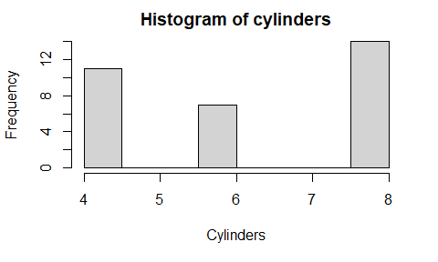

```r
hist(mtcars$cyl,
     main="Histogram of cylinders",
     xlab="Cylinders")
```

- Make a comparable graph using ggplot2 with x-axis label ‘Cylinders’, y-axis label ‘Frequency’, and title ‘Histogram of Cylinders’

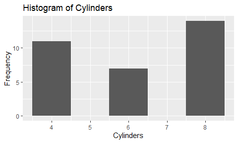

```r
ggplot(data = mtcars,
       aes(x = cyl)
       ) + labs(title = "Histogram of Cylinders"
       ) + geom_histogram(binwidth = 1
       ) + xlab("Cylinders"
       ) + ylab("Frequency")
```

## Q7.2 Label a scatter plot

This is an example of a plot generated using `subset()` and `geom_text()` in ggplot using the mtcars dataset. (1 point)

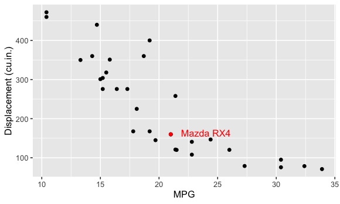

Scatter plot generated using mtcars with datapoint labeled.

Recreate this plot using ggplot as best you can.

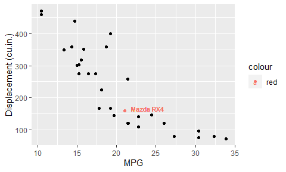

```r
ggplot(data = mtcars,
       aes(x = mpg, y = disp)
       ) + xlab("MPG"
       ) + ylab("Displacement (cu.in.)"
       ) + geom_point(
       ) + geom_point(data = mtcars["Mazda RX4", ],
                      aes(x = mpg, y = disp, color = "red")
       ) + geom_text(aes(x = mtcars["Mazda RX4", "mpg"] + 3, y = mtcars["Mazda RX4", "disp"] + 5, label = "Mazda RX4", color = "red"), size = 3)
```

# Question 8. Analyze Lord of the Rings (LOR) ( 3 pts )

Its often said that we should “write code for humans, write data for computers”.

- An important aspect of “writing data for computers”
  - is to make your data **tidy**.

Key features of **tidy** data:

- Each column is a variable
- Each row is an observation

If you are struggling to make a figure, for example,

- stop and think hard about whether your data is tidy.

Untidiness is a common, often overlooked

- cause of agony in data analysis
- and data visualization.

I will give you a concrete example of some untidy data

```r
library(tidyverse)
fotr <- read.csv('./data/2108The_Fellowship_Of_The_Ring.csv')
rotk <- read.csv('./data/2108The_Return_Of_The_King.csv')
tt <- read.csv('./data/2108The_Two_Towers.csv')

glimpse(fotr)
```

```
Rows: 3
Columns: 4
$ Film   <chr> "The Fellowship Of The Ring", "The Fellowship Of The Ring", "The Fellowship Of The Ring"
$ Race   <chr> "Elf", "Hobbit", "Man"
$ Female <int> 1229, 14, 0
$ Male   <int> 971, 3644, 1995
```

```r
glimpse(rotk)
```

```
Rows: 3
Columns: 4
$ Film   <chr> "The Return Of The King", "The Return Of The King", "The Return Of The King"
$ Race   <chr> "Elf", "Hobbit", "Man"
$ Female <int> 183, 2, 268
$ Male   <int> 510, 2673, 2459
```

```r
glimpse(tt)
```

```
Rows: 3
Columns: 4
$ Film   <chr> "The Two Towers", "The Two Towers", "The Two Towers"
$ Race   <chr> "Elf", "Hobbit", "Man"
$ Female <int> 331, 0, 401
$ Male   <int> 513, 2463, 3589
```

We have one table per movie.

- In each table, we have the total number of words spoken,
- by characters of different races and genders.

You could imagine finding these three tables

- as separate worksheets in an Excel workbook.
- Or hanging out in some cells on the side of a worksheet
  - that contains the underlying raw data.
- Or as tables on a webpage or in a Word document.

This data has been formatted for consumption by human eyeballs.

- The format makes it easy for a human
  - to look up the number of words spoken
  - by female elves in The Two Towers.

But this format actually

- makes it pretty hard for a computer
  - to pull out such counts
- and, more importantly,
  - to compute on them or graph them.

## Q8.1 Basics of tidy data

An important aspect of “writing data for computers”

- is to make your data **tidy**.

Two key features of **tidy** data are:

ANSWER <- 1. Each column is a variable ANSWER <- 2. Each row is an observation

## Q8.2 Basic data questions

Just looking at these tables, answer these questions:

(You’ll do this with code in the next part)

- What’s the total number of words spoken by male hobbits in each of the three movies?

Answer <- 3644 + 2673 + 2463 = 8780

- Does a certain Race dominate a movie?

Answer <- yes, FOTR -> Hobbit, ROTK -> Man, TT -> Man

- Does the dominant Race differ across the movies?

Answer <- yes, FOTR -> Hobbit, ROTK -> Man, TT -> Man

## Q8.3 Scalability

How well does your approach scale

- If there were many more movies
- or if I provided you with updated data
  - that includes all the Races
  - (e.g. dwarves, orcs, etc.)?

Answer <- It wouldn’t scale well because the data is melted down among the three datasets, and may require dcast and mutate. (Long DataSet)

```r
lotr <- read.csv('./data/2108lotr-tidy.csv')
glimpse(lotr)
```

```
Rows: 18
Columns: 4
$ Film   <chr> "The Fellowship Of The Ring", "The Fellowship Of The Ring", "The Fellowship Of The Ring", "The Two Towers", "The Two Towers", "The Two Tower…
$ Race   <chr> "Elf", "Hobbit", "Man", "Elf", "Hobbit", "Man", "Elf", "Hobbit", "Man", "Elf", "Hobbit", "Man", "Elf", "Hobbit", "Man", "Elf", "Hobbit", "Ma…
$ Gender <chr> "Female", "Female", "Female", "Female", "Female", "Female", "Female", "Female", "Female", "Male", "Male", "Male", "Male", "Male", "Male", "M…
$ Words  <int> 1229, 14, 0, 331, 0, 401, 183, 2, 268, 971, 3644, 1995, 513, 2463, 3589, 510, 2673, 2459
```

Notice that tidy data is generally taller and narrower.

- It doesn’t fit nicely on the page.
- Certain elements get repeated a lot,
  - e.g. `Hobbit`.

For these reasons,

- we often instinctively resist **tidy** data
  - as inefficient or ugly.

But, unless and until you’re making the final product

- for a textual presentation of data,
- ignore your yearning to see the data in a compact form.

Now using tidyverse packages, pipes and dplyr

- answer the following questions

## Q8.4 Analyzing total words

What’s the total number of words spoken by male hobbits?

```r
sum(lotr$Words[lotr$Gender == "Male" & lotr$Race == "Hobbit"])
```

```
[1] 8780
```

Answer <- 8780

## Q8.5 Analyzing words by film and race

Does a certain race dominate a movie?

Does the dominant race differ across the movies?

- You’ll first want to sum across gender,
  - to obtain word counts for the different races by movie.

```r
lotr$Race <- as.factor(lotr$Race)
lotr$Gender <- as.factor(lotr$Gender)
lotrByRace <- dcast(lotr, Film + Race + Words ~ Gender)
glimpse(lotrByRace)
```

```
Rows: 18
Columns: 5
$ Film   <chr> "The Fellowship Of The Ring", "The Fellowship Of The Ring", "The Fellowship Of The Ring", "The Fellowship Of The Ring", "The Fellowship Of T…
$ Race   <fct> Elf, Elf, Hobbit, Hobbit, Man, Man, Elf, Elf, Hobbit, Hobbit, Man, Man, Elf, Elf, Hobbit, Hobbit, Man, Man
$ Words  <int> 971, 1229, 14, 3644, 0, 1995, 183, 510, 2, 2673, 268, 2459, 331, 513, 0, 2463, 401, 3589
$ Female <int> NA, 1229, 14, NA, 0, NA, 183, NA, 2, NA, 268, NA, 331, NA, 0, NA, 401, NA
$ Male   <int> 971, NA, NA, 3644, NA, 1995, NA, 510, NA, 2673, NA, 2459, NA, 513, NA, 2463, NA, 3589
```

## Q8.6 Visualize Results

Now using ggplot2 let us visualize these results.

We can stare hard at those numbers to answer the question.

- But its even nicer to depict the word counts
  - we just computed in a barchart.